# HW 4

SDS322E

September 29, 2021

## Vaishnavi Sathiyamoorthy vs25229

**Please submit as a knitted HTML file on Canvas before the due date.**

*For all questions, include the R commands/functions that you used to find your answer. Answers without supporting code will not receive credit.*

#### Review of how to submit this assignment

> All homework assignments will be completed using R Markdown. These `.Rmd` files consist of >text/syntax (formatted using Markdown) alongside embedded R code. When you have completed the assignment (by adding R code inside codeblocks and supporting text outside of the codeblocks), create your document as follows:
> - Click the arrow next to the “Knit” button (above)
> - Choose “Knit to HTML”
> - Go to Files pane and put checkmark next to the correct HTML file
> - Click on the blue gear icon (“More”) and click Export
> - Download the file and then upload to Canvas

## Question 1:

### 1.1 (2 pts)

##### Load the ggplot2 package, which contains the mpg dataset. It contains data from 38 popular car models in 1999 and in 2008. Using ggplot, make a histogram of `hwy` (EPA highway miles-per-gallon). Then, in a separate plot, use `stat_ecdf()` to make a cumulative density plot of the same variable. The bimodal distribution is most clear in the histogram, but how can you see it in the cumulative density plot? Eyeballing the cumulative density plot, approximately what proportion of cars have a highway mpg of 20 or less? (if you want, confirm your suspicions by using mean on a logical vector).

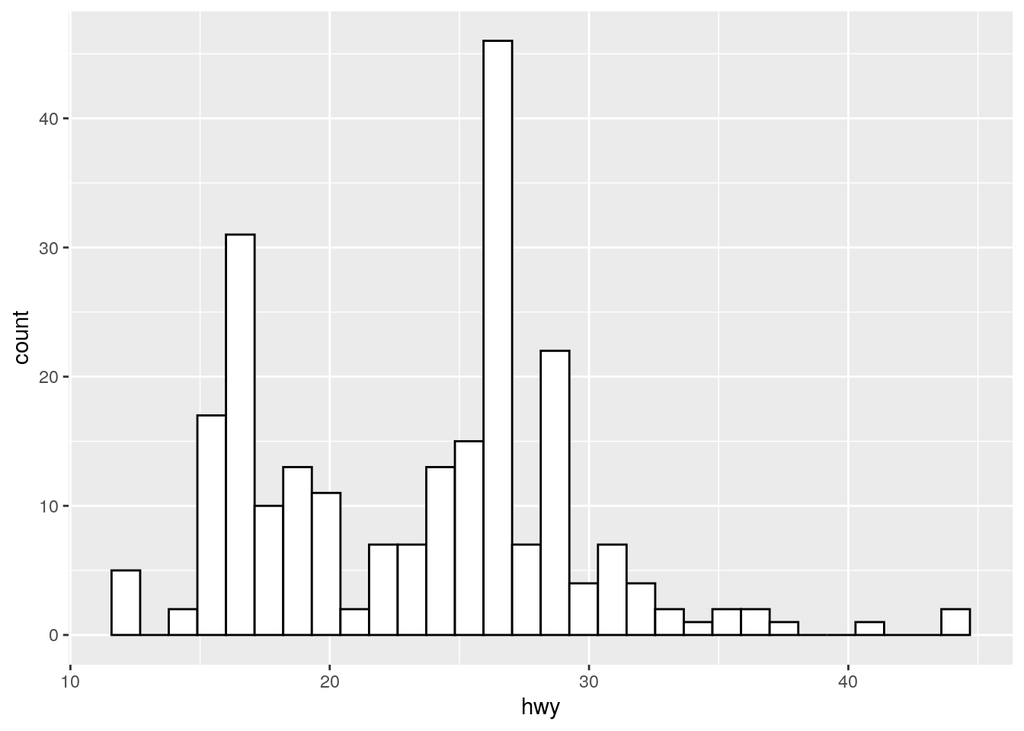

```r
library(ggplot2)
mpg <- as.data.frame(mpg)
ggplot(data = mpg, mapping = aes(x = hwy)) + geom_histogram(color = "black",
    fill = "white")
```

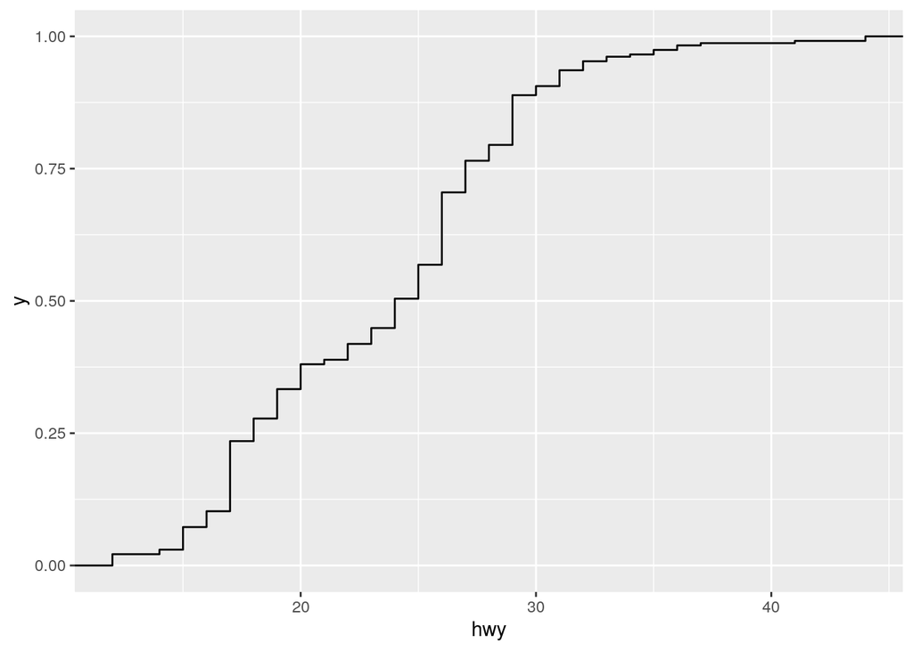

```r
ggplot(data = mpg, mapping = aes(x = hwy)) + stat_ecdf()
```

```r
sum(as.numeric(mpg$hwy <= 20))/nrow(mpg)
```

```
## [1] 0.3803419
```

*38% of cars have a highway mpg of 20 or less.*

### 1.2 (2 pts)

##### Now then, make a density plot of `cty` (city miles-per-gallon) and fill it by `class` of car. Add an alpha value of .8 to increase transparency. Eyeballing the plot, which two classes have the most overlap in their distributions? Which class has the least variation in `cty` mpg and which class has the most?

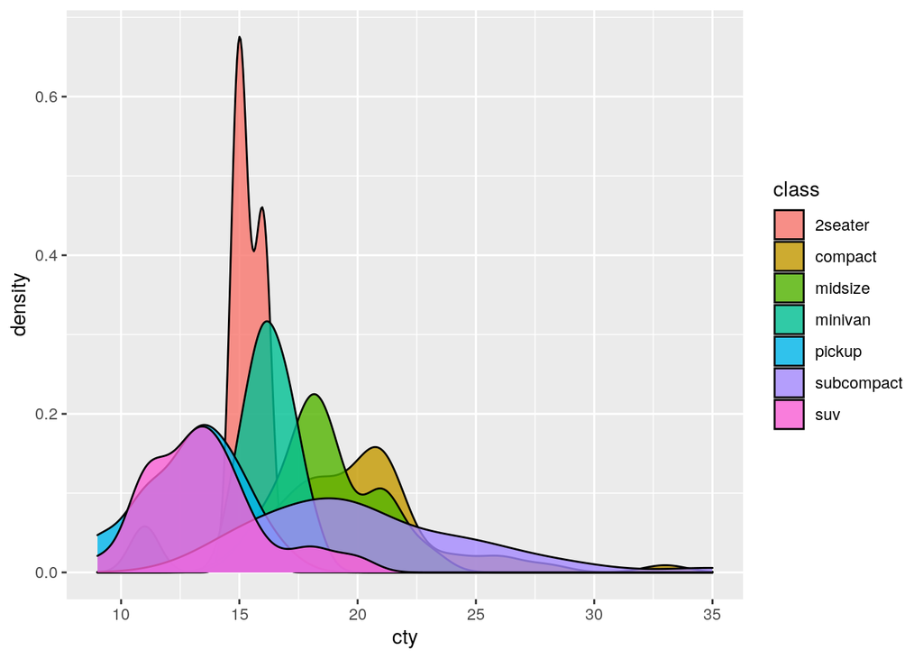

```r
ggplot(mpg, aes(x = cty, fill = class)) + geom_density(alpha = 0.8)
```

*The 2 classes that overlap the most are pick up and SUV. Subcompact has the most variation and 2 seaters have the least variation.*

### 1.3 (2 pts)

##### Take your density plot from 1.2 and use `facet_grid()` to create a separate row for each `class` (remove alpha here if you want). Next, add the argument `scales="free_y"` to `facet_grid()` and describe in words what effect it has (compared to leaving it off) and how it could be potentially misleading.

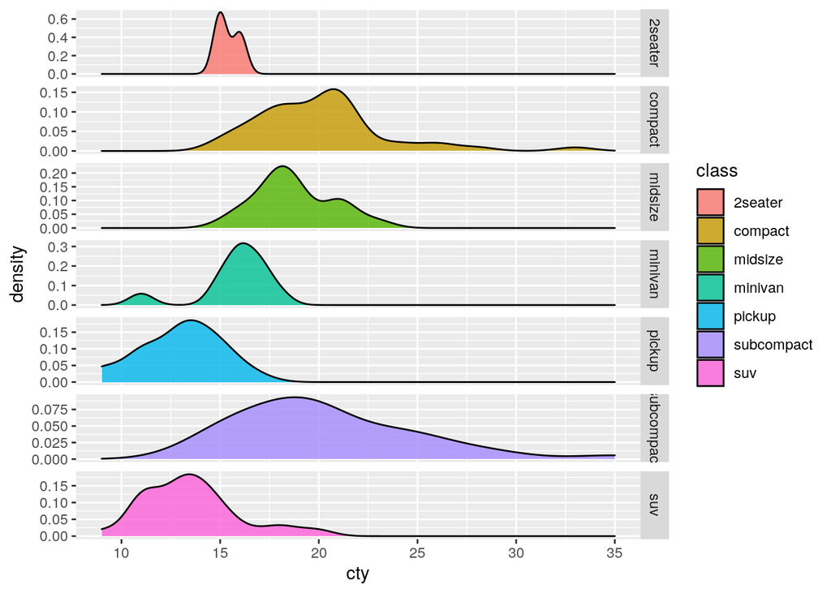

```r
ggplot(mpg, aes(x = cty, fill = class)) + geom_density(alpha = 0.8) +
    facet_grid(class ~ ., scales = "free_y")
```

*Setting scales to “free_y” allows for the data to be seen more clearly by changing the y range. This can be misleading because the values cannot be compared equally. These plots look like they have similar densities when not paying attention to the y axis.*

### 1.4 (2 pts)

##### Finally, make a two-dimensional density plot (using, e.g., `geom_density2d_filled`) to visualize the joint distribution of `cty` and `hwy`. Add `geom_jitter()` to show the data points but give a slight amount of random noise vertically and horizontally so that the points don’t totally overlap. Describe which areas of the plot show the greatest density of cars and which show the least density of cars in terms of their city and highway mpg.

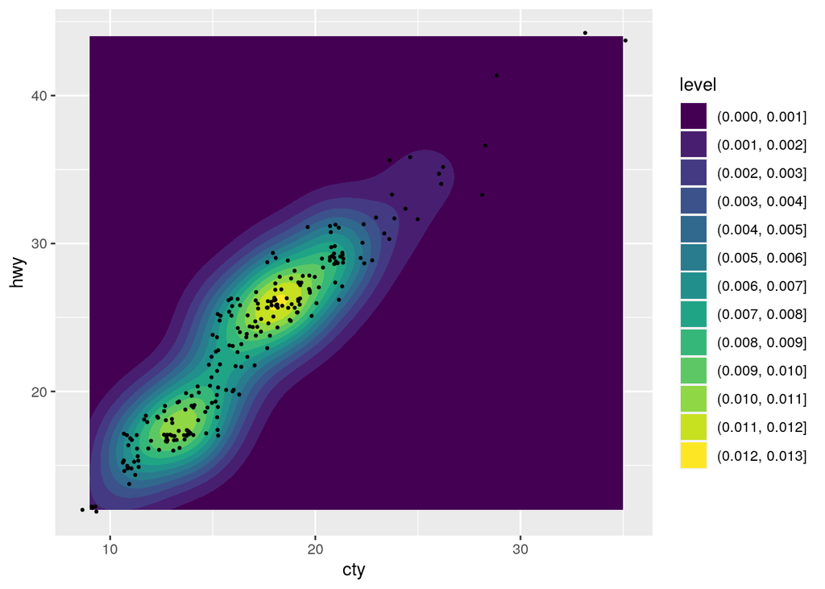

```r
ggplot(mpg, aes(x = cty, y = hwy)) + geom_density2d_filled() +
    geom_jitter(size = 0.5)
```

*The areas of the plot that have the highest density are those in the lighter shades. The areas of the plot that has the greatest density is when the city miles per gallon is 18 and the highway miles per gallon is 26 as well as when the city miles per gallon is 13 and the highway miles per gallon is 18. The areas that show the least amount of density are in dark purple. Those that have a highway miles per gallon greater than 35 and city miles per gallon greater than 30 have lower density.*

## Question 2

### 2.1 (1.5 pts)

##### Assume diastolic blood pressure is normally distributed in a certain population, with a mean of 67 mmHg and a standard deviation 13 mmHg. Use `pnorm()` to compute the probability of obtaining a value less than 60 mmHg from this distribution. Use `pnorm()` again to compute the probability of obtaining a value greater than 85 mmHg from this distribution. Finally, use `qnorm()` to find the 98th percentile of this distribution (the value which cuts of 98% of the distribution below it).

```r
pnorm(60, mean = 67, sd = 13)
```

```
## [1] 0.2951292
```

```r
pnorm(85, mean = 67, sd = 13, lower.tail = FALSE)
```

```
## [1] 0.08308505
```

```r
qnorm(0.98, mean = 67, sd = 13)
```

```
## [1] 93.69874
```

### 2.2 (1.5 pts)

##### Below, we set the seed to 322 with `set.seed()` so our random draws match. With `rnorm()` take a sample of size 10000 (ten thousand) draws from a normal distribution with a mean of 67 and a standard deviation of 13. Using `mean()` on a logical vector, what proportion of the total draws are less than 60? What proportion are greater than 85? Using `quantile()`, What value in your sample represents the 98th percentile?

```r
set.seed(322)  #leave this line alone

samp <- rnorm(n = 10000, mean = 67, sd = 13)

mean(as.logical(samp < 60))
```

```
## [1] 0.2954
```

```r
mean(as.logical(samp > 85))
```

```
## [1] 0.0864
```

```r
quantile(samp, probs = seq(0.98, 1, 0.98))
```

```
##      98%
## 93.88209
```

*29.54% of draws are less than 60 and 8.64% of the draws are greater than 85. 93.88 represents the 98th percentile.*

### 2.3 (1 pts)

##### Hopefully you see the correspondence between question 2.1 and question 2.2 Why are your answers to question 2.2 close to those in question 2.1 but not exactly the same?

*The answers are not the exact same because a sample was taken in 2.2.*

### 2.4 (4 pts)

##### Make your sample from question 2 into a dataframe and, using ggplot2, make a histogram of the sample by mapping the sample to the x-axis in the main `ggplot()` function and then adding the code `geom_histogram(aes(y=..density..))`. Then, overlay an density plot by adding `geom_density()`. Using `geom_vline(xintercept=)`, add solid vertical lines corresponding to the 2.5th and the 97.5th percentile of the sample (i.e., using `quantile`). Next overlay an actual normal distribution with a mean of 67 and a standard deviation of 13 using `geom_line()` with `dnorm` and `stat="function"`. Make it a different color to differentiate it from the empirical/sample density. Finally, using `geom_vline(xintercept=)`, add dashed vertical lines of the same new color corresponding to the 2.5th and the 97.5th percentile of the actual normal distribution (i.e., using `qnorm`).

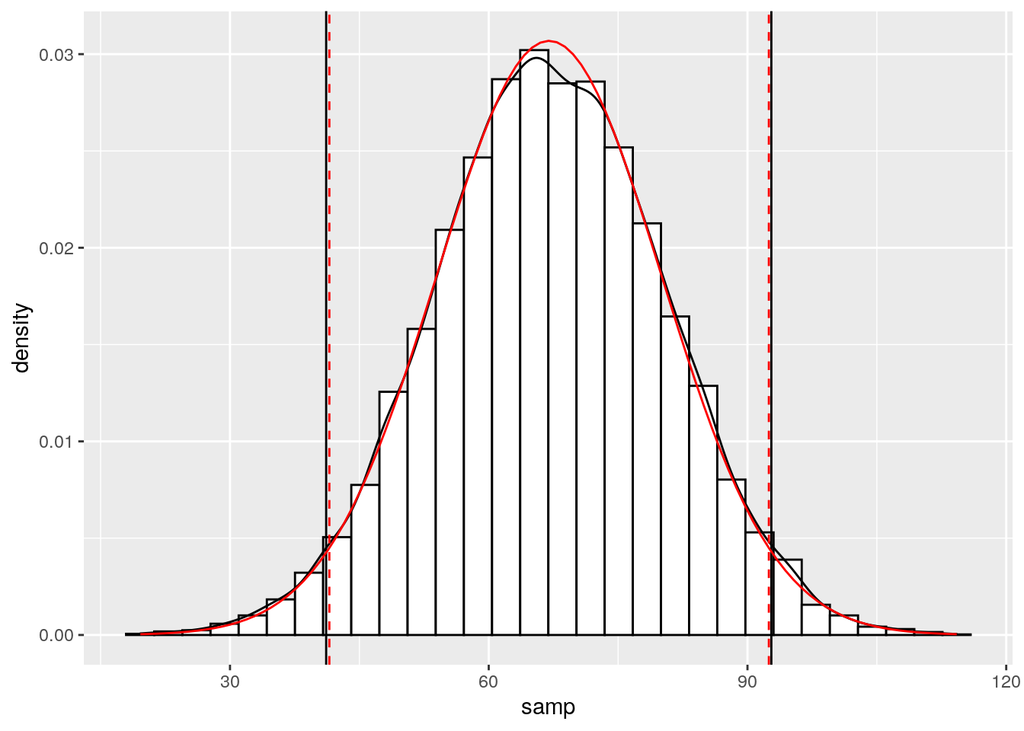

```r
library(ggplot2)
df <- data.frame(samp)  #makes your sample a column of a dataframe called df
ggplot(df, aes(x = samp)) + geom_histogram(aes(y = ..density..),
    color = "black", fill = "white") + geom_density() +
    geom_vline(xintercept = quantile(df$samp, probs = seq(0.025,
        0.025, 0.025))) + geom_vline(xintercept = quantile(df$samp,
    probs = seq(0.975, 0.975, 0.975))) + geom_line(stat = "function",
    fun = dnorm, args = list(mean = 67, sd = 13), color = "red") +
    geom_vline(xintercept = qnorm(0.025, 67, 13), linetype = "dashed",
        color = "red") + geom_vline(xintercept = qnorm(0.975,
    67, 13), linetype = "dashed", color = "red")
```

## Question 3

### 3.1 (2 pts)

##### Using `dplyr` functions (filter, summarize; do not use any [] or $) and the `quakes` dataset, What is the mean of the variable `mag` when `depth` is *greater than* the median depth? What is the mean of the variable `mag` when `depth` is *less than* the median depth?

```r
library(dplyr)
data(quakes)
quakes %>% filter(depth > median(depth)) %>% summarize(mean(mag))
```

```
##   mean(mag)
## 1    4.5232
```

```r
quakes %>% filter(depth < median(depth)) %>% summarize(mean(mag))
```

```
##   mean(mag)
## 1    4.7176
```

### 3.2 (1 pts)

##### Using `dplyr` and the `quakes` dataset, create a new variable called `depth_m` that gives `depth` in meters rather than kilometers. Use `mutate()` *only once* to achieve this! Do not use any [] or $.

```r
quakes %>% mutate(depth_m = depth * 1000)
```

```
##         lat   long depth mag stations depth_m
## 1    -20.42 181.62   562 4.8       41  562000
## 2    -20.62 181.03   650 4.2       15  650000
## 3    -26.00 184.10    42 5.4       43   42000
## 4    -17.97 181.66   626 4.1       19  626000
## 5    -20.42 181.96   649 4.0       11  649000
## 6    -19.68 184.31   195 4.0       12  195000
## 7    -11.70 166.10    82 4.8       43   82000
## 8    -28.11 181.93   194 4.4       15  194000
## 9    -28.74 181.74   211 4.7       35  211000
## 10   -17.47 179.59   622 4.3       19  622000
## 11   -21.44 180.69   583 4.4       13  583000
## 12   -12.26 167.00   249 4.6       16  249000
## 13   -18.54 182.11   554 4.4       19  554000
## 14   -21.00 181.66   600 4.4       10  600000
```

[output cut: 986 more lines]

### 3.3 (1 pts)

##### Finally, using ggplot, take the quakes dataset and make a scatterplot of `long` (x-axis) and `lat` (y-axis) and color the points by `depth`. Add `coord_map()` to scale axes with mercator projection (if this doesn’t work, use coord_fixed to make x- and y-axis scales the same). Optionally, add the extra code below to overlay world map data for this region using the code provided below.

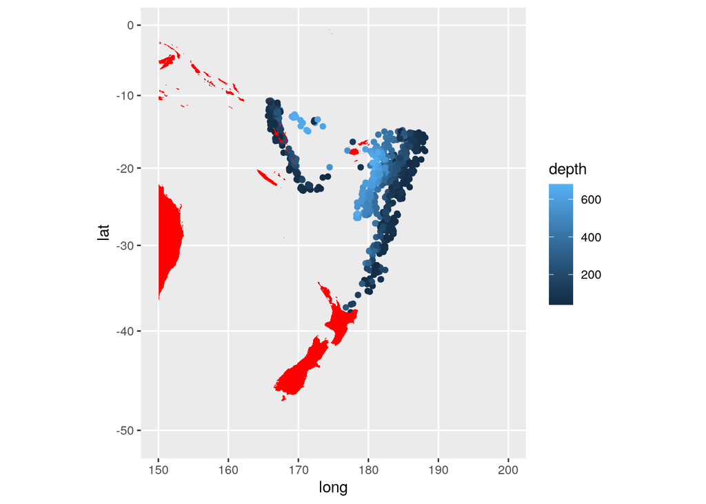

```r
library(tidyverse)
library(maps)  #install.packages('maps') if not on the servers
world <- map_data("world")
ggplot(quakes) + geom_point(aes(long, lat, color = depth)) +
    geom_polygon(aes(long, lat, group = group), data = world,
        fill = "red") + xlim(150, 200) + ylim(-50,
    0) + coord_map()
```

```r
# if you want to overlay a map, uncomment/add the
# following code to your plot:
#+geom_polygon(aes(long, lat, group=group), data = world, fill = 'red') + xlim(150,200)+ylim(-50,0)
```

```
## [1] "2021-09-29 22:08:52 CDT"
```

[output not shown]